# Grove Assessments: Existing Plots

Shive Lab (B. Baker)

2025-01-07

# Overview

Grove assessments are planned for each giant sequoia grove within the boundary of Sequoia Kings Canyon NP. These assessments will allow for the prioritization of treatment efforts within the park to ensure the protection of this valued resource. The assessments will be informed by data from SEKI’s longstanding FMH program, bolstered by data from other projects collecting relevant data in the parks. These include projects done by SEKI’s fire effects program, USGS, and the Shive Lab at UCB in partnership with SEKI. In addition to utilizing existing plots, additional data will be collected at plots added as needed throughout the groves.

This overview outlines the existing plots in the park that can be used for grove assessment, but is missing the drought plots done by SEKI Fire Effects. It includes a section summarizing existing plots and plot density in all groves as well as plot characteristics across all groves (“All groves”), followed by a section showing summaries of plot characteristics for individual groves and ends with a set of questions that we will need input from the group on.

## All groves

The tabs below outline the characteristics of the groves in the park and give an overview of the existing plots that are in the groves.

```r
groves <- st_as_sf(groves)

#buffer groves by 75m
groves_seki_buffered <- st_buffer(groves, dist = 75)

#calc area and select SEKI only
groves_seki_buffered <- groves_seki_buffered %>%
  # calculate ha area of buffered groves
  mutate(withbufferarea_ha = as.numeric(st_area(groves_seki_buffered)*0.0001)) %>%
  filter(grepl("NPS SEKI", land_ste_1)) %>% #seki only
  select(-land_ste_1)

#Note i do think there are a few groves that overlap when buffered
#some area might be duplicated
#minimal but likely worth fixing long term

groves_seki_summary <- groves_seki_buffered %>%
  st_drop_geometry() %>%
  mutate(groveacres = round(grovearea_ha*2.47, 2),
         grove_wbuffer_acres = round(withbufferarea_ha*2.47, 2))

median_grove <- median(groves_seki_summary$groveacres)
mean_grove <- mean(groves_seki_summary$groveacres)

median_grovewbuf <- median(groves_seki_summary$grove_wbuffer_acres)
mean_grovewbuf <- mean(groves_seki_summary$grove_wbuffer_acres)

groves_seki_summary_total <- groves_seki_summary %>%
  select(grove_name, contains("acres")) %>%
  adorn_totals()

#write_csv(groves_seki_summary, here("outputs/groves_seki_summary.csv"))
```

There are 39 groves within the SEKI boundary ranging from 0.3 acres to 2615 acres with a total of 11195 acres. The smallest groves are defined by individual trees (Putnam-Francis Tree and Fenced Tree while the largest are thousands of acres (Redwood Mountain and Giant Forest). The median grove size is 48 acres and the mean is 287 acres.

The above areas are estimated with the minimalist grove boundary layer. Since the grove assessments are intended to identify areas where treatment would be effective to reinforce grove resilience to wildfire, we buffered the layer by 75m to encompass area where fire behavior from outside the groves can impact the groves themselves and account for where the grove boundary is too small.

### Plot overview

```r
#only plots within groves
all_plots_groves <- st_intersection(all_plots, groves_seki_buffered)

#make grove summary plot, nonspatial
groves_summary <- all_plots_groves %>%
  st_drop_geometry() %>% #remove polygon reference
  summarize(.by = c(grove_name, project), plot_count = n()) %>% #count per type
  pivot_wider(names_from = project, # make wider dataframe for viz
              values_from = plot_count,
              values_fill = 0) %>%
  adorn_totals("col") %>% #calc total plots per grove
  adorn_totals() %>%  #calc total plots per type
  left_join(groves_seki_summary_total) %>% # add grove info
  mutate(plots_peracre_buf = round(Total/grove_wbuffer_acres,2),
         acres_perplot_buf = round(grove_wbuffer_acres/Total, 2))
```

Grove assessments will use plots from a variety of projects. There are 288 plots from 7 projects. There are 16 groves with plots. Redwood Mountain has the most plots by count.

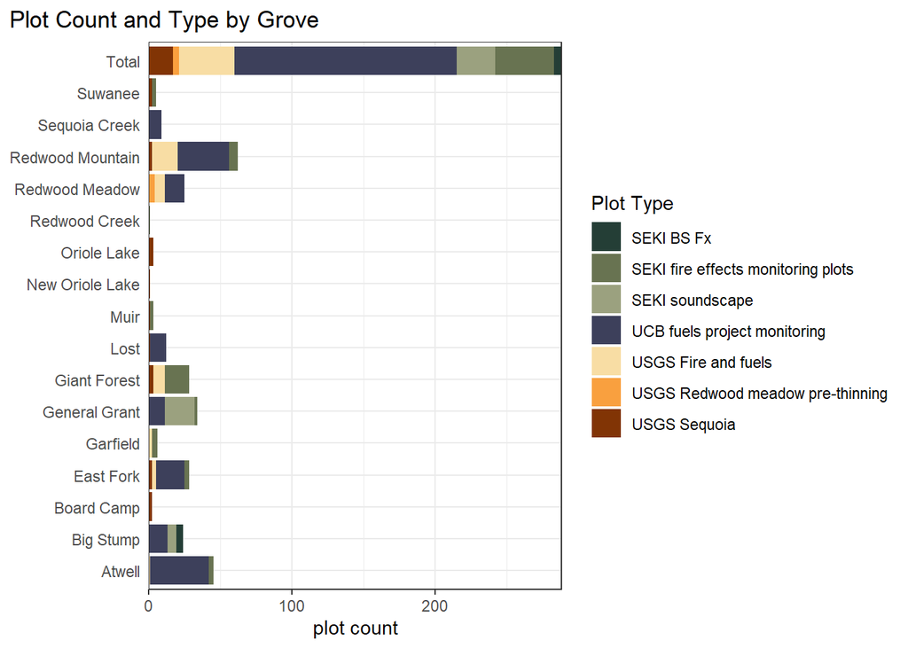

```r
# rearrange for plotting
groves_summary_longer <- groves_summary %>%
  pivot_longer(`SEKI fire effects monitoring plots`:Total,
               names_to = "project",
               values_to = "plot_count") %>%
  filter(!project == "Total") %>%
  left_join(plot_colors) #attach colors (needed for individual)

# define plot colors
colors <- distinct(groves_summary_longer, project, color) %>% tibble::deframe()

# figure of plot types
ggplot(groves_summary_longer, aes(grove_name, plot_count, fill = project))+
  geom_col()+
  labs(
    y = "plot count",
    title = "Plot Count and Type by Grove"
  )+
  scale_fill_manual(
    name = "Plot Type",
    values = colors) +
  coord_flip()+
  theme_bw()+
  theme(
    plot.title.position = "plot",
    axis.ticks.y=element_blank(),
    axis.title.y = element_blank(),
    )+
  scale_y_continuous(expand = c(0, 0))
```

```r
#save plot
#ggsave(here("outputs/plotcount.jpg"), width = 7, height = 5, units = "in", dpi = 600)
groves_summary_plots <-select(groves_summary, grove_name:Total) %>%
  rename("Grove" = grove_name)

#table of plot breakdown
kable(groves_summary_plots,
      digits = 2,
      caption = "Plot Breakdown by Grove")
```

Plot Breakdown by Grove

| Grove | SEKI fire effects monitoring plots | UCB fuels project monitoring | USGS Fire and fuels | SEKI BS Fx | SEKI soundscape | USGS Sequoia | USGS Redwood meadow pre-thinning | Total |
| --- | --- | --- | --- | --- | --- | --- | --- | --- |
| Atwell | 3 | 41 | 1 | 0 | 0 | 0 | 0 | 45 |
| Big Stump | 0 | 13 | 0 | 5 | 6 | 0 | 0 | 24 |
| Board Camp | 0 | 0 | 0 | 0 | 0 | 2 | 0 | 2 |
| East Fork | 3 | 20 | 3 | 0 | 0 | 2 | 0 | 28 |
| Garfield | 4 | 0 | 2 | 0 | 0 | 0 | 0 | 6 |
| Giant Forest | 17 | 0 | 8 | 0 | 0 | 3 | 0 | 28 |
| Lost | 0 | 11 | 0 | 0 | 0 | 1 | 0 | 12 |
| Muir | 2 | 0 | 0 | 0 | 0 | 1 | 0 | 3 |
| New Oriole Lake | 0 | 0 | 0 | 0 | 0 | 1 | 0 | 1 |
| Oriole Lake | 0 | 0 | 0 | 0 | 0 | 3 | 0 | 3 |
| Redwood Creek | 1 | 0 | 0 | 0 | 0 | 0 | 0 | 1 |
| Redwood Meadow | 0 | 14 | 7 | 0 | 0 | 0 | 4 | 25 |
| Sequoia Creek | 0 | 9 | 0 | 0 | 0 | 0 | 0 | 9 |
| Suwanee | 3 | 0 | 0 | 0 | 0 | 2 | 0 | 5 |
| Redwood Mountain | 6 | 36 | 18 | 0 | 0 | 2 | 0 | 62 |
| General Grant | 2 | 11 | 0 | 0 | 21 | 0 | 0 | 34 |
| Total | 41 | 155 | 39 | 5 | 27 | 17 | 4 | 288 |

Of the groves with plots, Sequoia Creek and Lost Grove have high proportions of plots whereas Garfield has a very low density. Because of the range of grove area, it is not feasible to intend on even plot density across groves.

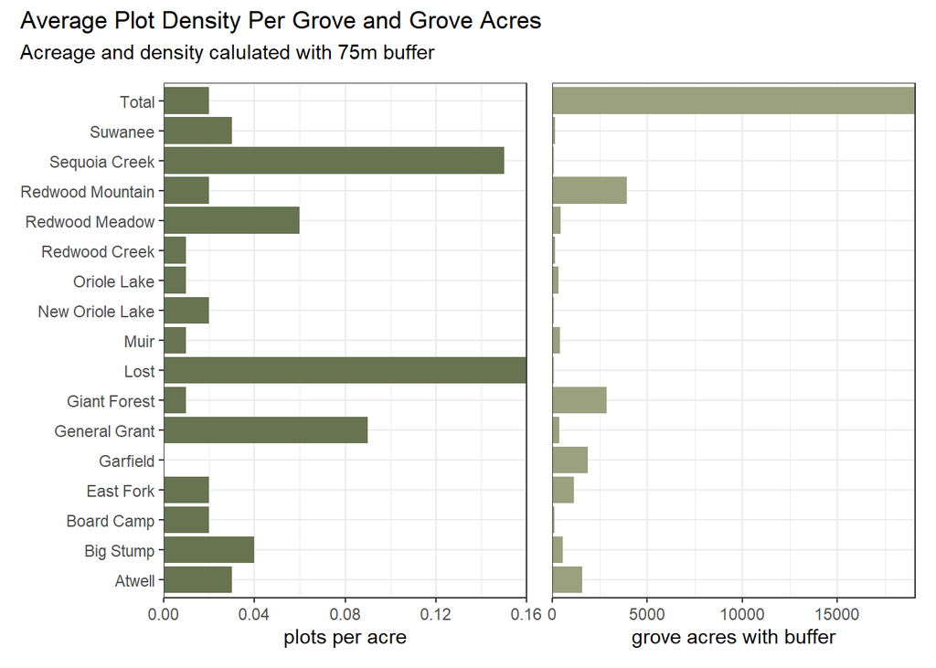

```r
#plots per acre in groves
density <- ggplot(groves_summary, aes(grove_name, plots_peracre_buf))+
  geom_col(fill = "#687351")+
  coord_flip()+
  labs(
    y = "plots per acre"
  )+
  theme_bw()+
  theme(axis.title.y = element_blank())+
  scale_y_continuous(expand = c(0, 0))+
  theme(axis.title.y = element_blank())

#total acerage of groves
acres <- ggplot(groves_summary, aes(grove_name, grove_wbuffer_acres))+
  geom_col(fill = "#9ba17f")+
  coord_flip()+
  labs(
    y = "grove acres with buffer"
  )+
  theme_bw()+
  theme(
    axis.ticks.y=element_blank(),
    axis.title.y = element_blank(),
    axis.text.y = element_blank() #remove axis labels
  )+
  scale_y_continuous(expand = c(0, 0))

density+acres+plot_annotation("Average Plot Density Per Grove and Grove Acres", subtitle = "Acreage and density calulated with 75m buffer")
```

```r
ggsave(here("outputs/plotdensity_acres.jpg"), width = 7, height = 5, units = "in", dpi = 600)
```

```r
summary_plotacres <- groves_summary %>%
  select(grove_name, plots_peracre_buf, acres_perplot_buf) %>%
  arrange(plots_peracre_buf)

#table of plot breakdown
kable(summary_plotacres,
      digits = 2,
      caption = "Plot Count versus Acres",
      col.names = c("Grove", "Plots per acre", "Acres per plot"))
```

Plot Count versus Acres

| Grove | Plots per acre | Acres per plot |
| --- | --- | --- |
| Garfield | 0.00 | 313.85 |
| Giant Forest | 0.01 | 101.78 |
| Muir | 0.01 | 132.16 |
| Oriole Lake | 0.01 | 106.81 |
| Redwood Creek | 0.01 | 154.69 |
| Board Camp | 0.02 | 58.18 |
| East Fork | 0.02 | 41.15 |
| New Oriole Lake | 0.02 | 62.04 |
| Redwood Mountain | 0.02 | 63.04 |
| Total | 0.02 | 66.32 |
| Atwell | 0.03 | 34.74 |
| Suwanee | 0.03 | 30.25 |
| Big Stump | 0.04 | 22.48 |
| Redwood Meadow | 0.06 | 17.98 |
| General Grant | 0.09 | 10.65 |
| Sequoia Creek | 0.15 | 6.77 |
| Lost | 0.16 | 6.35 |

```r
#make lookup ids
all_plots_groves <- rowid_to_column(all_plots_groves)

#convert to terra object
all_vect <- vect(all_plots_groves)

# topography info per plot
env_plots <- terra::extract(env_stack, all_vect) %>%
  left_join(all_plots_groves, by = join_by(ID == rowid)) %>%
  rename(elevation_m = So_Sierra_DEM_10m,
         slope_perc = So_Sierra_10mDEM_slopePercent,
         aspect = So_Sierra_10mDEM_aspect) %>%
  left_join(plot_colors) #add color reference


#fire in each plot
fire_plot <- extract(fire, all_vect)%>%
  replace_na(list(
    id = "none",
    fire_yr = "0000",
    burnsev = 0,
    asss_t = "none")) %>%
  rename(ID = id.y)

fire_plot_recent <- fire_plot %>%
  group_by(ID) %>%
  slice_max(fire_yr) %>%
  mutate(
    burnsev = case_when(
      burnsev == 0 ~ "Unburned",
      burnsev == 1 ~ "Undetected change",
      burnsev == 2 ~ "Low",
      burnsev == 3 ~ "Moderate",
      burnsev == 4 ~ "High"
    ),
  burnsev = factor(burnsev,ordered = T, levels = c("Unburned", "Undetected change", "Low", "Moderate", "High") )
  )

burnsev_plot <- fire_plot_recent %>%
  ungroup() %>%
  summarise(.by = burnsev, count = n())

fire_plot_count <- fire_plot %>%
  filter(fire_yr != "0000") %>%
  summarise(.by = c(ID), fire_count = n())


env_plots <- env_plots %>%
  left_join(fire_plot_count) %>%
  left_join(fire_plot_recent) %>%
  replace_na(list(fire_count = 0))
```

### Fire history

```r
summary_fire_amount <- fire_plot %>%
  drop_na() %>%
  summarize(.by = ID, fire_count = n()) %>%
  summarize(.by = fire_count, plot_count = n())

summary_fire_amount <- summary_fire_amount%>%
  add_row(fire_count = 0, plot_count = nrow(env_plots)-sum(summary_fire_amount$plot_count)) %>%
  arrange(fire_count)

kable(summary_fire_amount,
      caption = "Plot Breakdown by Number of Wildfires",
      booktabs = T,
      col.names = c("Fire count", "Plot count"))
```

Plot Breakdown by Number of Wildfires

| Fire count | Plot count |
| --- | --- |
| 0 | 124 |
| 1 | 148 |
| 2 | 16 |

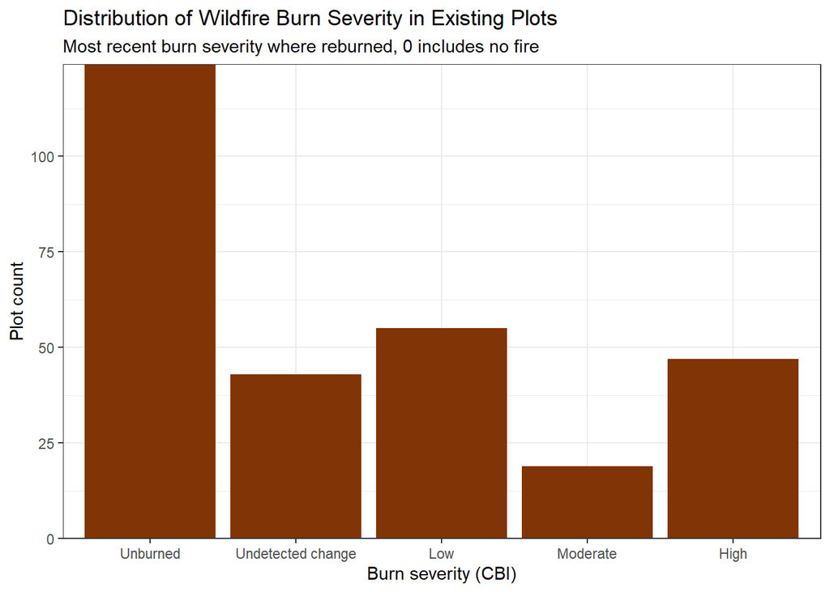

```r
ggplot(burnsev_plot, aes(burnsev, count))+
  geom_col(fill = "#813405")+
  labs(
    title = "Distribution of Wildfire Burn Severity in Existing Plots",
    subtitle = "Most recent burn severity where reburned, 0 includes no fire",
    y = "Plot count",
    x = "Burn severity (CBI)"
  )+
  theme_bw()+
  scale_y_continuous(expand = c(0, 0))#+
```

```r
  #scale_x_continuous(expand = c(0, 0))
ggsave(here("outputs/burnsev.jpg"), width = 7, height = 5, units = "in", dpi = 600)
```

### Topographic characteristics

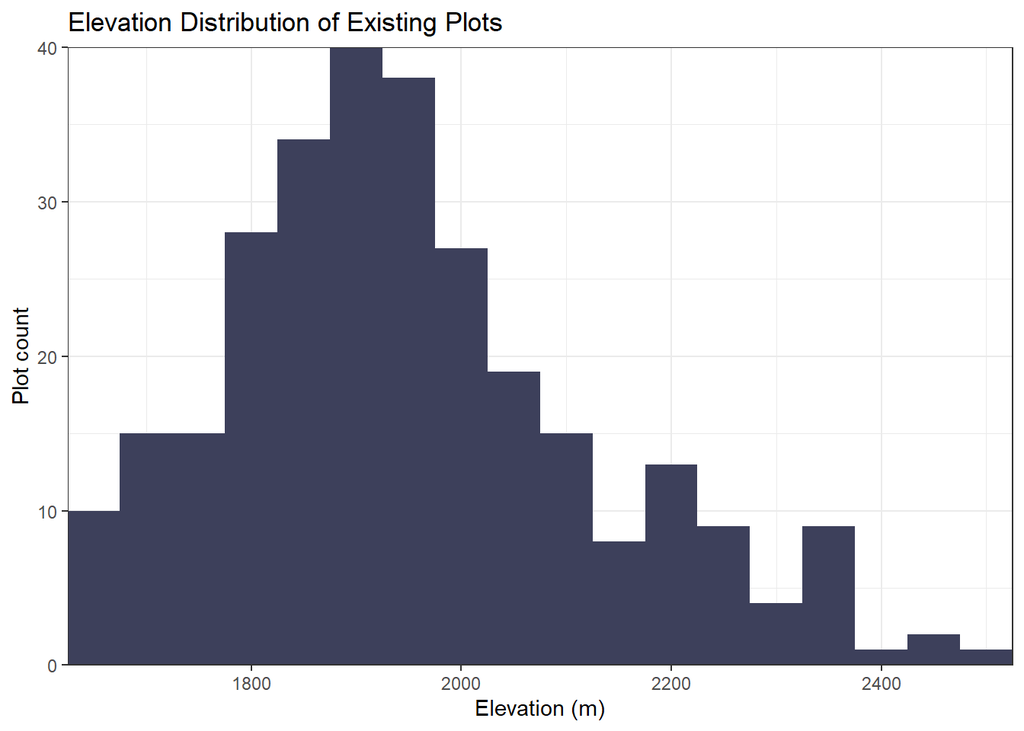

```r
ggplot(env_plots, aes(x=elevation_m))+
  geom_histogram(fill = "#3d405b", binwidth = 50)+
  labs(
    title = "Elevation Distribution of Existing Plots",
    y = "Plot count",
    x = "Elevation (m)"
  )+
  theme_bw()+
  scale_y_continuous(expand = c(0, 0))+
  scale_x_continuous(expand = c(0, 0))
```

```r
ggsave(here("outputs/elev.jpg"), width = 7, height = 5, units = "in", dpi = 600)
```

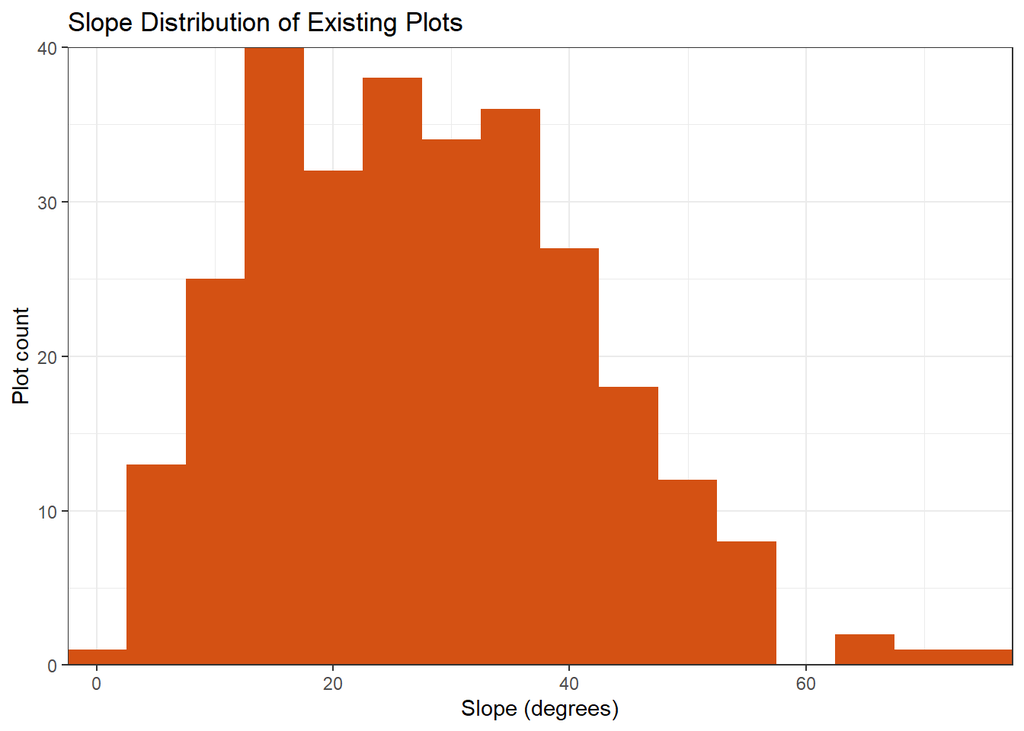

```r
ggplot(env_plots, aes(x=slope_perc))+
  geom_histogram(fill="#d45113", binwidth = 5)+
  labs(
    title = "Slope Distribution of Existing Plots",
    y = "Plot count",
    x = "Slope (degrees)"
  )+
   scale_y_continuous(expand = c(0, 0))+
  scale_x_continuous(expand = c(0, 0))+
  theme_bw()
```

```r
ggsave(here("outputs/slope.jpg"), width = 7, height = 5, units = "in", dpi = 600)
```

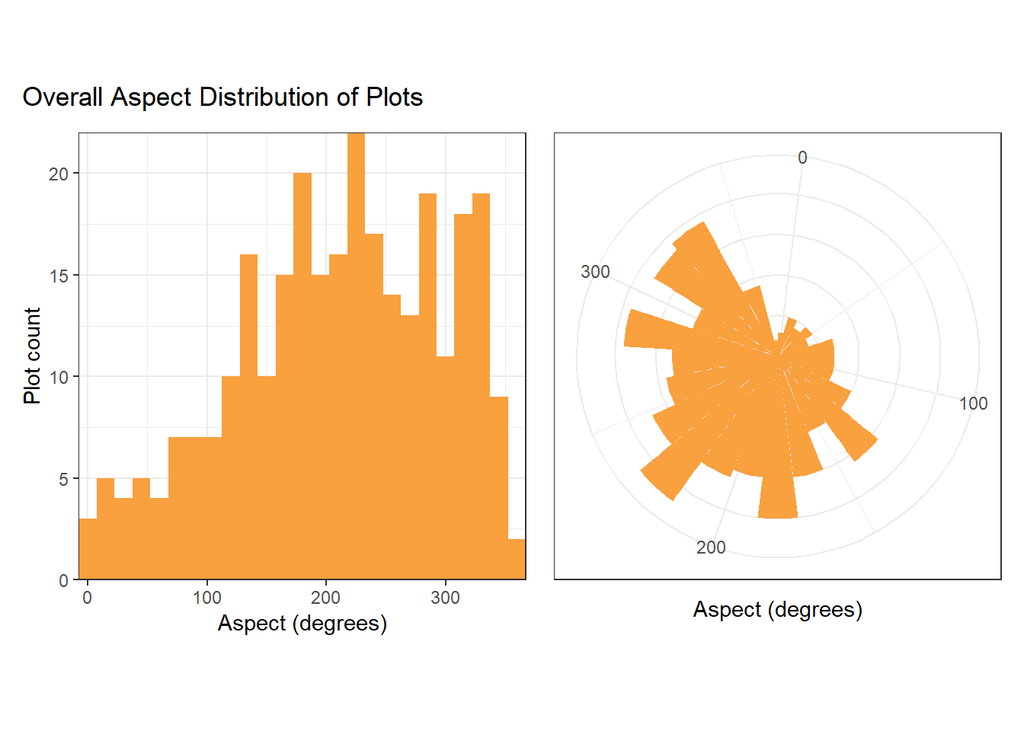

```r
aspect_polar <- ggplot(env_plots, aes(x=aspect))+
  geom_histogram(fill="#f9a03f", binwidth = 15)+
  labs(
    y = "Plot count",
    x = "Aspect (degrees)"
  )+
  theme_bw()+
  coord_polar()+
  scale_y_continuous(expand = c(0, 0))+
  scale_x_continuous(expand = c(0, 0)) +
   theme(
    axis.ticks.y=element_blank(),
    axis.title.y = element_blank(),
    axis.text.y = element_blank() )#remove axis labels

aspect_graph <- ggplot(env_plots, aes(x=aspect))+
  geom_histogram(fill = "#f9a03f", binwidth = 15)+
  labs(
    y = "Plot count",
    x = "Aspect (degrees)"
  )+
  theme_bw()+
  scale_y_continuous(expand = c(0, 0))+
  scale_x_continuous(expand = c(0, 0))

aspect_graph+aspect_polar+plot_annotation(title = "Overall Aspect Distribution of Plots")
```

```r
ggsave(here("outputs/aspect_combined.jpg"), width = 7, height = 5, units = "in", dpi = 600)
```

### Grove area table

```r
kable(groves_seki_summary_total,
      digits = 2,
      caption = "SEKI Grove Area Summary",
      booktabs = T,
      col.names = c("Grove", "Acres", "Acres with 75m buffer"))
```

SEKI Grove Area Summary

| Grove | Acres | Acres with 75m buffer |
| --- | --- | --- |
| Atwell | 914.89 | 1563.14 |
| Big Springs | 2.37 | 29.79 |
| Big Stump | 282.75 | 539.44 |
| Board Camp | 48.20 | 116.36 |
| Cahoon | 14.21 | 59.79 |
| Castle Creek | 218.63 | 520.15 |
| Cedar Flat | 15.21 | 79.13 |
| Clough Cave | 1.41 | 11.42 |
| Coffeepot Canyon | 5.94 | 25.28 |
| Dennison | 13.36 | 43.14 |
| Devil’s Canyon | 8.87 | 43.63 |
| Dillonwood | 1039.51 | 1928.19 |
| Douglass | 1.06 | 11.15 |
| East Fork | 741.76 | 1152.20 |
| Eden Creek | 434.83 | 802.84 |
| Forgotten | 1.83 | 14.71 |
| Garfield | 1232.42 | 1883.09 |
| Giant Forest | 2106.04 | 2849.78 |
| Granite Creek | 1.42 | 11.95 |
| Homers Nose | 118.83 | 276.26 |
| Horse Creek | 50.46 | 148.68 |
| Little Redwood Meadow | 27.92 | 64.81 |
| Lost | 35.40 | 76.25 |
| Muir | 244.89 | 396.47 |
| New Oriole Lake | 14.74 | 62.04 |
| Fenced Tree | 0.56 | 8.04 |
| Oriole Lake | 146.93 | 320.42 |
| Pine Ridge | 43.82 | 158.02 |
| Putnam-Francis Tree | 0.30 | 7.04 |
| Redwood Creek | 47.71 | 154.69 |
| Redwood Meadow | 179.24 | 449.57 |
| Sequoia Creek | 15.85 | 60.96 |
| Skagway | 60.94 | 147.72 |
| South Fork | 241.24 | 502.48 |
| Squirrel Creek | 6.99 | 55.17 |
| Surprise | 22.47 | 104.31 |
| Suwanee | 68.98 | 151.25 |
| Redwood Mountain | 2615.45 | 3908.67 |
| General Grant | 167.38 | 362.10 |
| Total | 11194.81 | 19100.13 |

## Individual grove plot comparison

The following are comparisons of grove strata and strata represented by plots in groves that have plots.

```r
groves_seki_buffered_vect <- vect(groves_seki_buffered)

groves_id <- rownames_to_column(groves_summary) %>%
  mutate(ID = as.numeric(rowname)) %>%
  select(ID, grove_name) %>%
  filter(grove_name != "Total")

grove_stats <- extract(env_stack, groves_seki_buffered_vect) %>%
  rename(elevation_m = So_Sierra_DEM_10m,
         slope_perc = So_Sierra_10mDEM_slopePercent,
         aspect = So_Sierra_10mDEM_aspect) %>%
  left_join(groves_id) %>%
  rename()

groves_fire <- intersect(fire, groves_seki_buffered_vect) %>%
  st_as_sf() %>%
  group_by(grove_name, id) %>%
  mutate(fire_yr = as.numeric(fire_yr)) %>%
  slice_max(fire_yr) %>%
  ungroup() %>%
  mutate(area_ha = as.numeric(st_area(.))*0.0001,
         prop_grove = area_ha/withbufferarea_ha)


grove_list <- groves_id$grove_name
```

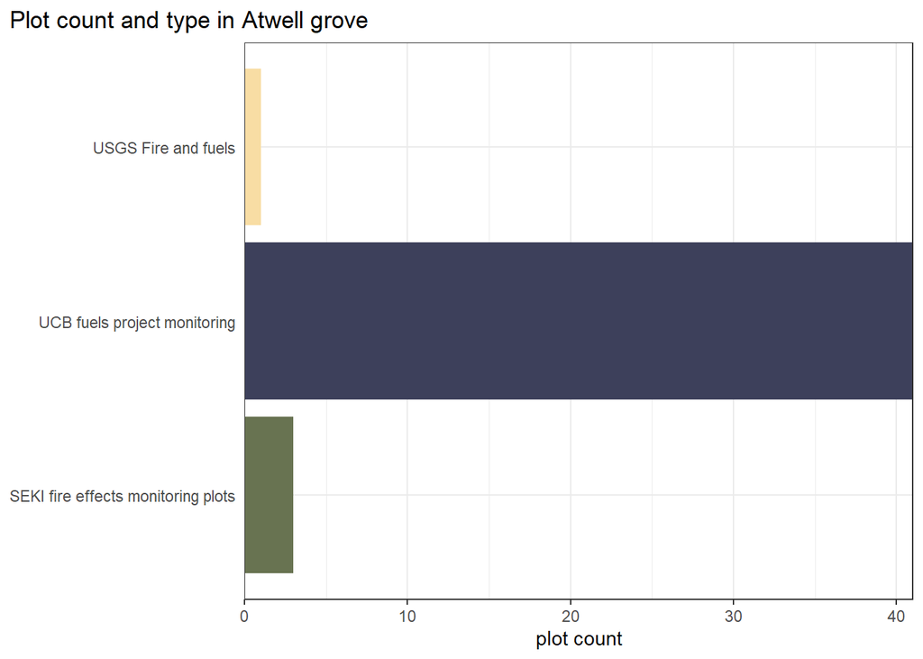

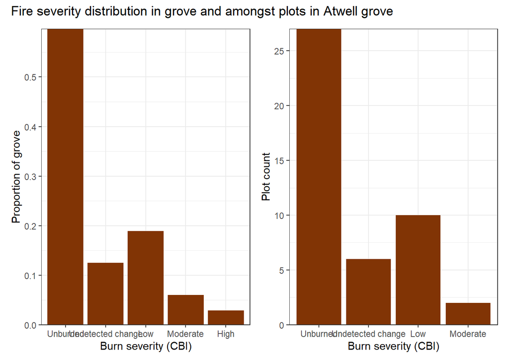

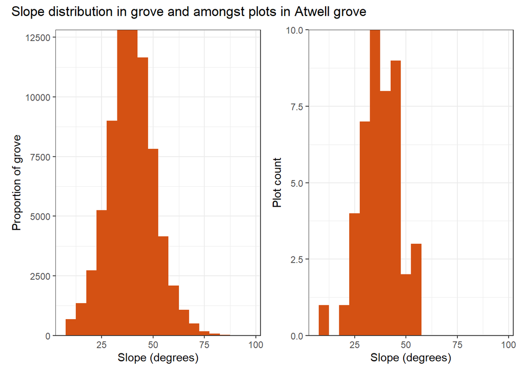

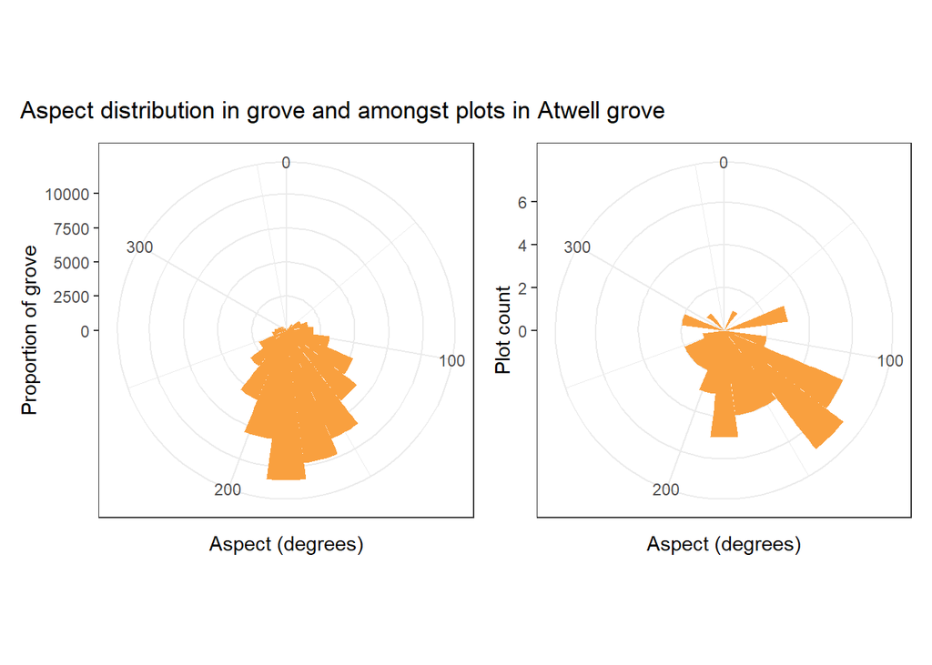

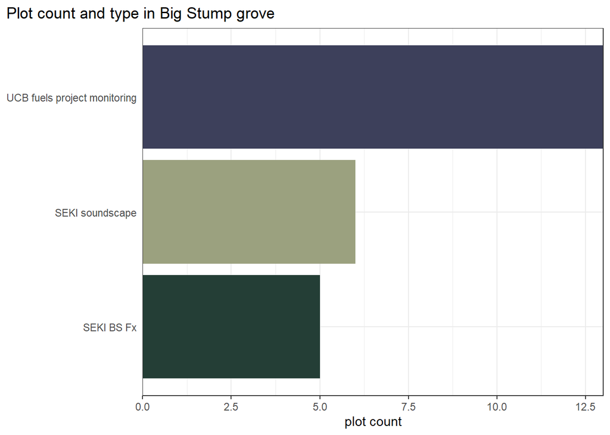

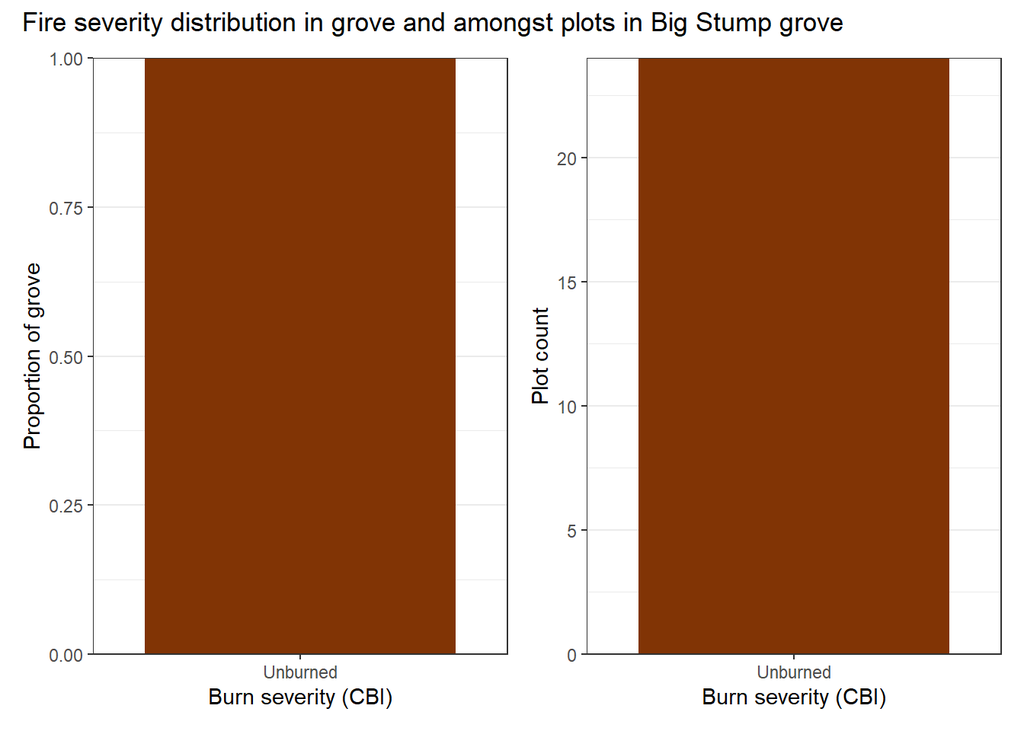

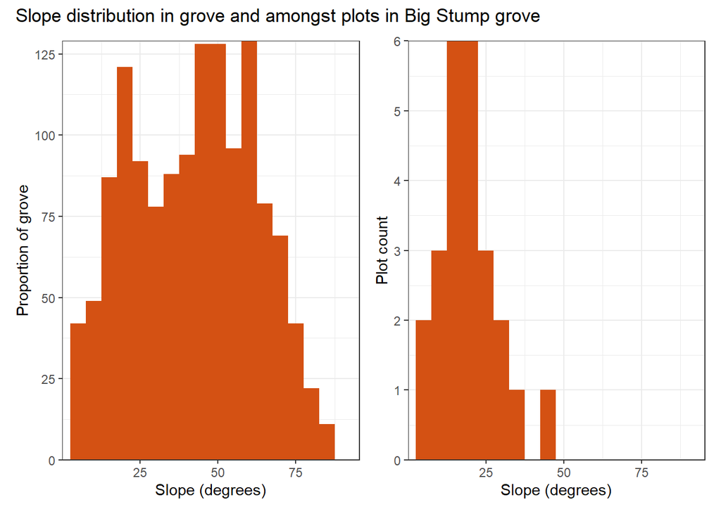

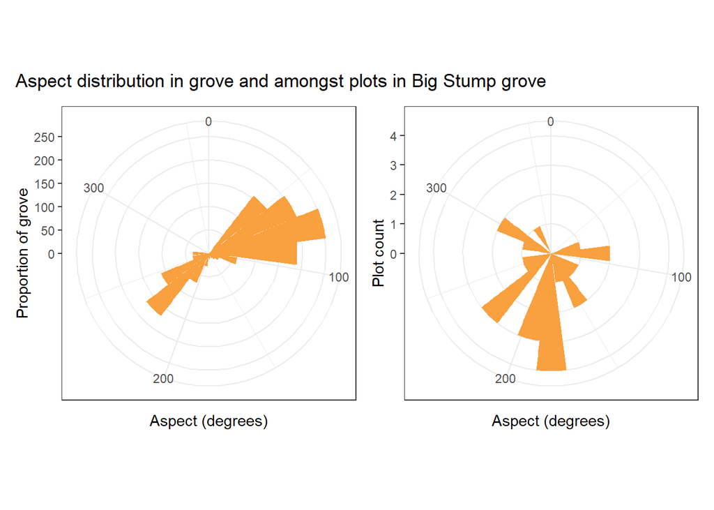

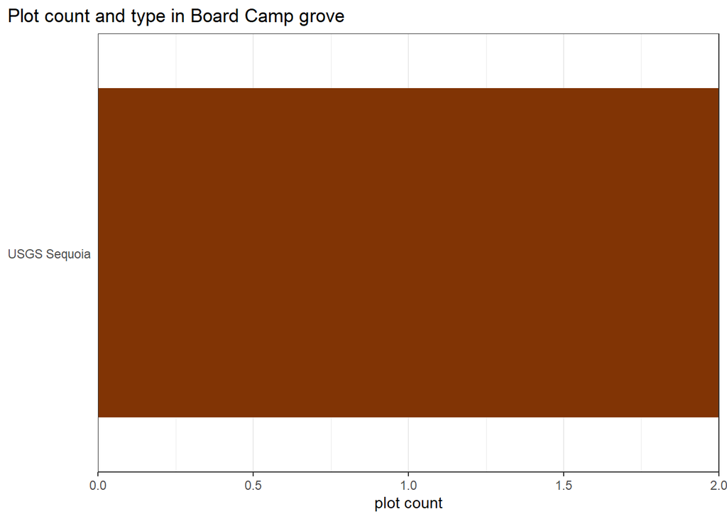

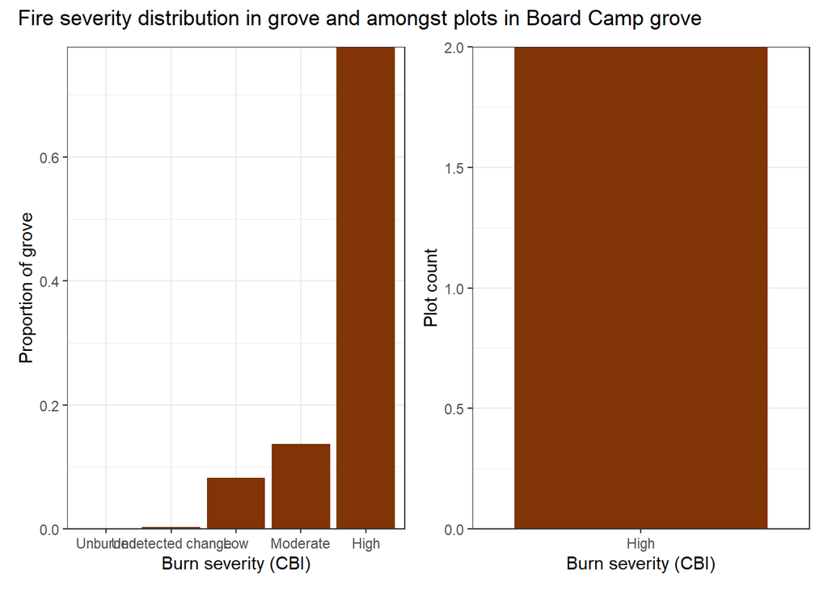

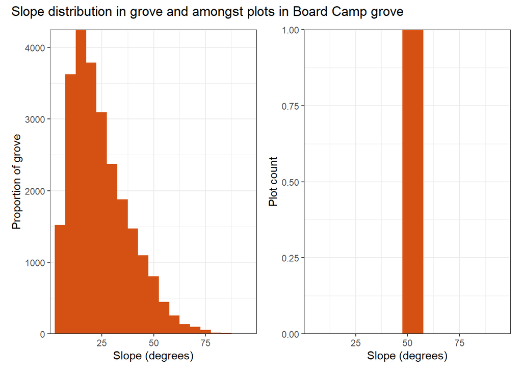

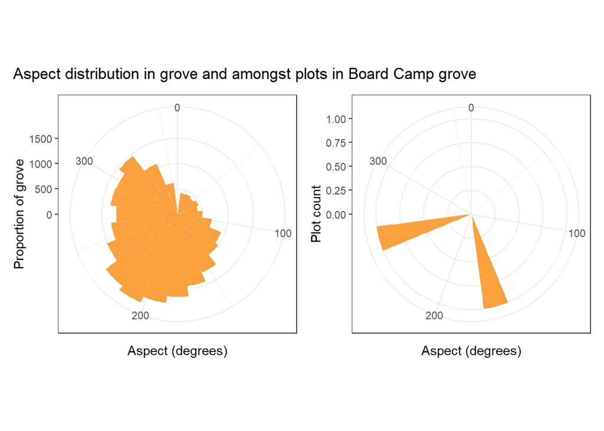

[52 more figures not shown]

```r
for (i in grove_list) {

grove <- i

indiv_plots <- filter(env_plots, grove_name == grove)

#burnsev plot setup
indiv_fire <- filter(groves_fire, grove_name == grove)

burnsev_totals <- indiv_fire %>%
  st_drop_geometry() %>%
  summarize(.by = burnsev, prop_grove = sum(prop_grove))

fire_totals <- burnsev_totals %>%
  add_row(burnsev = 0, prop_grove = 1-sum(burnsev_totals$prop_grove)) %>%
  mutate(
    burnsev = case_when(
      burnsev == 0 ~ "Unburned",
      burnsev == 1 ~ "Undetected change",
      burnsev == 2 ~ "Low",
      burnsev == 3 ~ "Moderate",
      burnsev == 4 ~ "High",
      T ~ "Unburned"
    ),
  burnsev = factor(burnsev,ordered = T, levels = c("Unburned", "Undetected change", "Low", "Moderate", "High") )
  )

plots_burnsev <- indiv_plots %>%
  summarize(.by = burnsev, count = n()) %>%
  arrange(burnsev)

#grove stats info
indiv_grove <- filter(grove_stats, grove_name == grove)
indiv_summary <- filter(groves_summary, grove_name == grove)

colors <- distinct(indiv_plots, project, color) %>% tibble::deframe()

# plot of project types
projects <- ggplot(indiv_plots, aes(project, fill = project))+
  geom_bar()+
  labs(
    y = "plot count",
    title = paste("Plot count and type in", grove, "grove")
  )+
  scale_fill_manual(values = colors) +
  coord_flip()+
  theme_bw()+
  theme(
    plot.title.position = "plot",
    axis.ticks.y=element_blank(),
    axis.title.y = element_blank(),
    legend.position = "none"
    )+
  scale_y_continuous(expand = c(0, 0))

#come back and add fire piece
p_fire <- ggplot(plots_burnsev, aes(burnsev, count))+
  geom_col(fill = "#813405")+
  labs(y = "Plot count",
       x = "Burn severity (CBI)")+
  theme_bw()+
  scale_y_continuous(expand = c(0, 0))

g_fire <- ggplot(fire_totals, aes(burnsev, prop_grove))+
  geom_col(fill = "#813405")+
  labs(y = "Proportion of grove",
       x = "Burn severity (CBI)")+
  theme_bw()+
  scale_y_continuous(expand = c(0, 0))


p_slope <- ggplot(indiv_plots, aes(x=slope_perc))+
  geom_histogram(fill="#d45113", binwidth = 5)+
  labs(
    y = "Plot count",
    x = "Slope (degrees)"
  )+
   scale_y_continuous(expand = c(0, 0))+
  scale_x_continuous(expand = c(0, 0),
                     limits = c(min(indiv_grove$slope_perc), max(indiv_grove$slope_perc)))+
  theme_bw()

g_slope <- ggplot(indiv_grove, aes(x=slope_perc))+
  geom_histogram(fill="#d45113", binwidth = 5)+
  labs(
    y = "Proportion of grove",
    x = "Slope (degrees)"
  )+
  scale_y_continuous(expand = c(0, 0))+
  scale_x_continuous(expand = c(0, 0),
                     limits = c(min(indiv_grove$slope_perc), max(indiv_grove$slope_perc)))+
  theme_bw()

p_aspect <- ggplot(indiv_plots, aes(x=aspect))+
  geom_histogram(fill="#f9a03f", binwidth = 15)+
  labs(
    y = "Plot count",
    x = "Aspect (degrees)"
  )+
  theme_bw()+
  coord_polar()+
  scale_y_continuous(expand = c(0, 0))+
  scale_x_continuous(expand = c(0, 0), limits = c(0, 360)) +
  theme_bw()

g_aspect <- ggplot(indiv_grove, aes(x=aspect))+
  geom_histogram(fill="#f9a03f", binwidth = 15)+
  labs(
    y = "Proportion of grove",
    x = "Aspect (degrees)"
  )+
  theme_bw()+
  coord_polar()+
  scale_y_continuous(expand = c(0, 0))+
  scale_x_continuous(expand = c(0, 0), limits = c(0, 360))

print(projects)

print(g_fire + p_fire + plot_annotation(title = paste("Fire severity distribution in grove and amongst plots in", grove, "grove")))

print(g_slope + p_slope + plot_annotation(title = paste("Slope distribution in grove and amongst plots in", grove, "grove")))

print(g_aspect + p_aspect + plot_annotation(title = paste("Aspect distribution in grove and amongst plots in", grove, "grove")))

}
```

## Sampling decisions for the workgroup

1. What factors are important to represent/stratify? *Our initial thought is that aspect and severity/disturbance history will be the most important variable and that it is worth considering topographic position*
2. How do we want to determine sampling intensity and stratification within a grove?
3. How much we can utilize inference to characterize the fuels structure of a grove? That is to say: to describe the needs of a given grove, how much of the data needs to come from direct plot observations in that grove versus plot observations from plots with similar characteristics in other groves? What counts as similar and what kind of ground truthing would be most feasible and useful?